# Wordcloud and Sentiment Analysis **Tears in Heaven** - Eric Clapton

```r
# Google developer API key
library(vosonSML)

apikey <- "AIzaSyBjszB1Ap335V9r-3IBd2QsUXbm-ZGiJ9s"
key <- Authenticate(
  "youtube",
  apiKey =
    "AIzaSyBjszB1Ap335V9r-3IBd2QsUXbm-ZGiJ9s")
```

```r
#Collect data using Youtube video IDs

video <- c('JxPj3GAYYZ0')
ytdata <- Collect(key, video, writeToFile = FALSE, maxComments = 1000)
```

```
## ---------------------------------------------------------------
## ** video Id: JxPj3GAYYZ0
## -- API returned more than max comments. Results truncated to first 1000 threads.
## ** Collected threads: 1000
## ** Collecting replies for 107 threads with replies. Please be patient.
## ...........................................................................................................
## ** Collected replies: 308
## ** Total video comments: 1308
## ---------------------------------------------------------------
## ** Total comments collected for all videos 1308.
## Done.
## Elapsed time: 0 hrs 1 mins 0 secs (60.23)
```

```r
str(ytdata)
```

```
## Classes 'dataource', 'youtube' and 'data.frame': 1308 obs. of  9 variables:
##  $ Comment           : chr  "Eric Clapton are Tears Fall for you.....We love you, keep on rocking" "Alguien que able en español aqui puro gringo😞" "J'ai dit au revoir à mon papa sur cette chanson en janvier dernier..\nJe t aime papa" "2019❤" ...
##  $ User              : chr  "Amy Lee" "Pablo Flores" "Magali Logez" "talia monteiro" ...
##  $ ReplyCount        : chr  "0" "0" "0" "0" ...
##  $ LikeCount         : chr  "0" "0" "0" "0" ...
##  $ PublishTime       : chr  "2019-10-07T01:48:32.000Z" "2019-10-06T23:19:50.000Z" "2019-10-06T22:39:23.000Z" "2019-10-06T14:48:32.000Z" ...
##  $ CommentId         : chr  "UgzS-zhfjlu4aD3vjGt4AaABAg" "UgxRnFJ16HhnqoBzA2t4AaABAg" "UgyuMKi8MFzZaJSliLF4AaABAg" "UgyPvii09YSdQ4X-qzB4AaABAg" ...
##  $ ParentID          : chr  "None" "None" "None" "None" ...
##  $ ReplyToAnotherUser: chr  "FALSE" "FALSE" "FALSE" "FALSE" ...
##  $ VideoID           : chr  "JxPj3GAYYZ0" "JxPj3GAYYZ0" "JxPj3GAYYZ0" "JxPj3GAYYZ0" ...
```

```r
write.csv(ytdata, file='yt.csv', row.names = FALSE)
```

```r
#Read youtube data filesdata

data <- read.csv(file.choose(), header = T)
str(data)
```

```
## 'data.frame':    1308 obs. of  9 variables:
##  $ Comment           : Factor w/ 1293 levels "\"...For u ,Dad , I didn't ever said to you how much I love u , I just silly boy who just want to proved to his"| __truncated__,..: 296 167 635 130 440 1263 87 856 564 754 ...
##  $ User              : Factor w/ 1156 levels "* Daboot *","*EAGLE* a c e",..: 88 821 665 1015 555 892 1013 299 740 709 ...
##  $ ReplyCount        : int  0 0 0 0 0 0 0 0 0 0 ...
##  $ LikeCount         : int  0 0 0 0 0 0 0 0 0 0 ...
##  $ PublishTime       : Factor w/ 1308 levels "2019-05-20T09:11:52.000Z",..: 1308 1307 1306 1299 1298 1296 1295 1292 1291 1288 ...
##  $ CommentId         : Factor w/ 1308 levels "Ugw-QzHrQYUWaOt0nu94AaABAg",..: 1214 601 956 912 1209 228 1217 999 845 38 ...
##  $ ParentID          : Factor w/ 108 levels "None","Ugw_RlO4kCMsUe2iW7B4AaABAg",..: 1 1 1 1 1 1 1 1 1 1 ...
##  $ ReplyToAnotherUser: Factor w/ 134 levels "Юлия Иду на Вы!",..: 39 39 39 39 39 39 39 39 39 39 ...
##  $ VideoID           : Factor w/ 1 level "JxPj3GAYYZ0": 1 1 1 1 1 1 1 1 1 1 ...
```

## Building Corpus

```r
#Build corpus
library(tm)
corpus <- iconv(data$Comment, to ="UTF-8")
corpus <- Corpus(VectorSource(corpus))
inspect(corpus[1:5])
```

```
## <<SimpleCorpus>>
## Metadata:  corpus specific: 1, document level (indexed): 0
## Content:  documents: 5
##
## [1] Eric Clapton are Tears Fall for you.....We love you, keep on rocking
## [2] Alguien que able en español aqui puro gringo😞
## [3] J'ai dit au revoir à mon papa sur cette chanson en janvier dernier..\nJe t aime papa
## [4] 2019❤
## [5] I am losing my wife to brian cancer
```

## Cleaning text

Here I am changing letters of the youtube comment to lowercase, removing punctuation, removing numbers, stops words(e.g. ‘I’, ‘you’, ‘and’, ‘the’, etc.), urls, spaces, and other words that are not useful.

```r
#Clean text
corpus <- tm_map(corpus, tolower)
inspect(corpus[1:5])
```

```
## <<SimpleCorpus>>
## Metadata:  corpus specific: 1, document level (indexed): 0
## Content:  documents: 5
##
## [1] eric clapton are tears fall for you.....we love you, keep on rocking
## [2] alguien que able en español aqui puro gringo<u+0001f61e>
## [3] j'ai dit au revoir à mon papa sur cette chanson en janvier dernier..\nje t aime papa
## [4] 2019<u+2764>
## [5] i am losing my wife to brian cancer
```

```r
corpus <- tm_map(corpus, removePunctuation)
inspect(corpus[1:5])
```

```
## <<SimpleCorpus>>
## Metadata:  corpus specific: 1, document level (indexed): 0
## Content:  documents: 5
##
## [1] eric clapton are tears fall for youwe love you keep on rocking
## [2] alguien que able en español aqui puro gringou0001f61e
## [3] jai dit au revoir à mon papa sur cette chanson en janvier dernier\nje t aime papa
## [4] 2019u2764
## [5] i am losing my wife to brian cancer
```

```r
corpus <- tm_map(corpus, removeNumbers)
inspect(corpus[1:5])
```

```
## <<SimpleCorpus>>
## Metadata:  corpus specific: 1, document level (indexed): 0
## Content:  documents: 5
##
## [1] eric clapton are tears fall for youwe love you keep on rocking
## [2] alguien que able en español aqui puro gringoufe
## [3] jai dit au revoir à mon papa sur cette chanson en janvier dernier\nje t aime papa
## [4] u
## [5] i am losing my wife to brian cancer
```

```r
cleanset <- tm_map(corpus, removeWords, stopwords('english'))
inspect(cleanset[1:5])
```

```
## <<SimpleCorpus>>
## Metadata:  corpus specific: 1, document level (indexed): 0
## Content:  documents: 5
##
## [1] eric clapton  tears fall  youwe love  keep  rocking
## [2] alguien que able en español aqui puro gringoufe
## [3] jai dit au revoir à mon papa sur cette chanson en janvier dernier\nje t aime papa
## [4] u
## [5]   losing  wife  brian cancer
```

```r
removeURL <- function(x) gsub('http[[:alnum:]]*','',x)
cleanset <- tm_map(cleanset, content_transformer(removeURL))
inspect(cleanset[1:20])
```

```
## <<SimpleCorpus>>
## Metadata:  corpus specific: 1, document level (indexed): 0
## Content:  documents: 20
##
##  [1] eric clapton  tears fall  youwe love  keep  rocking
##  [2] alguien que able en español aqui puro gringoufe
##  [3] jai dit au revoir à mon papa sur cette chanson en janvier dernier\nje t aime papa
##  [4] u
##  [5]   losing  wife  brian cancer
##  [6] working   song tonight  beloved bride passed away last week   want  play    service  dont know though  cant get   without crying   im afraid  will make everyone cry  thats     want   want us  celebrate  life   mourn  death  wish   think  something better
##  [7] uuue uu uuubucuc
##  [8] omg  wtf almost    versión still fills  tear    eyes…  puts everything  whole feeling   voice…  melodies… god  songs   lot  things  proof  blues   alive  wish  demo versión  released…   know     got   perfect perfect
##  [9]  think   mother   listen   song
## [10]  baby sister made   heaven    hope  will meet
## [11]  sincere feelings    lost someone ufe
## [12]  uncle play    grandma funeral ufufdufaufaufaufufufufbuf
## [13]  bf passed away   depresion killshe  always   heart  love   muchufduufefgoodbye  love ajcufd
## [14]    look like one   music videos  movie tracks o
## [15]  much paingodbless  son passed away   didicate  song   son
## [16]  song   hard  listen      little child    kills  every time  hear  yet  love   much  beautiful
## [17]  love  lyrics
## [18] old  gold
## [19]  song  played   beautiful uncles funeral  lost  life  lung cancer ufufuf  miss   much \nrip uncle george  youll never  forgotten  please come  get     time xxx  love   much xx uuuuuu
## [20]
```

```r
cleanset <- tm_map(cleanset, stripWhitespace)
inspect(cleanset[1:20])
```

```
## <<SimpleCorpus>>
## Metadata:  corpus specific: 1, document level (indexed): 0
## Content:  documents: 20
##
##  [1] eric clapton tears fall youwe love keep rocking
##  [2] alguien que able en español aqui puro gringoufe
##  [3] jai dit au revoir à mon papa sur cette chanson en janvier dernier je t aime papa
##  [4] u
##  [5]  losing wife brian cancer
##  [6] working song tonight beloved bride passed away last week want play service dont know though cant get without crying im afraid will make everyone cry thats want want us celebrate life mourn death wish think something better
##  [7] uuue uu uuubucuc
##  [8] omg wtf almost versión still fills tear eyes… puts everything whole feeling voice… melodies… god songs lot things proof blues alive wish demo versión released… know got perfect perfect
##  [9]  think mother listen song
## [10]  baby sister made heaven hope will meet
## [11]  sincere feelings lost someone ufe
## [12]  uncle play grandma funeral ufufdufaufaufaufufufufbuf
## [13]  bf passed away depresion killshe always heart love muchufduufefgoodbye love ajcufd
## [14]  look like one music videos movie tracks o
## [15]  much paingodbless son passed away didicate song son
## [16]  song hard listen little child kills every time hear yet love much beautiful
## [17]  love lyrics
## [18] old gold
## [19]  song played beautiful uncles funeral lost life lung cancer ufufuf miss much rip uncle george youll never forgotten please come get time xxx love much xx uuuuuu
## [20]
```

```r
cleanset <- tm_map(cleanset, removeWords, c('song', 'ufufuf', 'uufef','got','get','made','someone','ever','sure','thats','listen'))
```

## Barplot of Corpus

This is a bar plot of the corpus and includes the frequency of an individual words occurance.

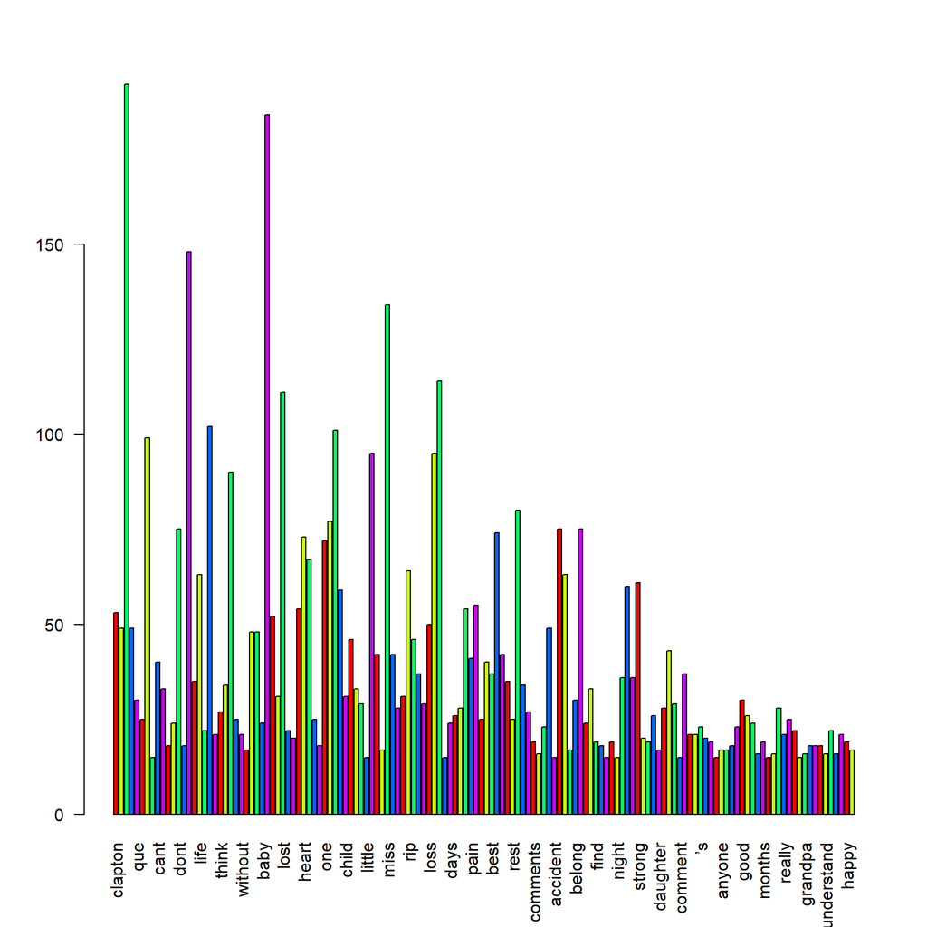

```r
#Barplot
w <- rowSums(tdm)
w <- subset(w, w>= 15)
barplot(w,
        las = 2,
        col = rainbow(5))
```

## Wordcloud of Corpus

This visual shows the frequency of occurence by displaying words with higher frequency in larger text and towards the center, and words with lower frequency spiraling out towards the edge of the word cloud and in smaller text.

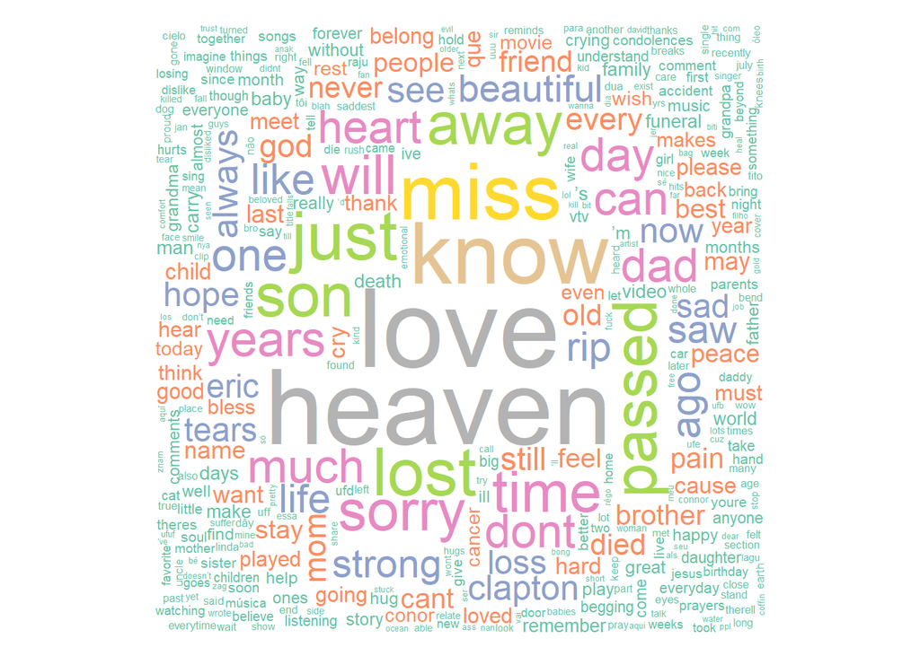

```r
#wordcloud
library(wordcloud)
w <- sort(rowSums(tdm), decreasing = TRUE)
set.seed(222)
wordcloud(words = names(w),
          freq = w,
          random.color = FALSE,
          random.order = FALSE,
          colors = brewer.pal(8, 'Set2'),
          scale = c(5, 0.3),
          rot.per = .15)
```

## Wordcloud # 2

This word cloud is interactive, allowing you to hover over any given word and displaying how often the word occurs in our data set.

```r
#wordcloud2
library(wordcloud2)
w <- data.frame(names(w), w)
colnames(w) <- c('word', 'freq')
wordcloud2(w,
           size = 0.5,
           shape = 'triangle',
           rotateRatio = 0.25,
           minSize = 1,
           color = 'random-light')
```

[interactive chart not shown]

Sentiment Analysis By using the Syuzhet package, here we will conduct a sentiment analysis of the comments of Tears in heaven. We will be using the get_nrc_sentiment function here to do our sentiment analysis. Here is a brief description for this function found here directly on the r-project website.https://cran.r-project.org/web/packages/syuzhet/vignettes/syuzhet-vignette.html

“The get_nrc_sentiment implements Saif Mohammad’s NRC Emotion lexicon. According to Mohammad, “the NRC emotion lexicon is a list of words and their associations with eight emotions (anger, fear, anticipation, trust, surprise, sadness, joy, and disgust) and two sentiments (negative and positive)” (See http://www.purl.org/net/NRCemotionlexicon). The get_nrc_sentiment function returns a data frame in which each row represents a sentence from the original file. The columns include one for each emotion type was well as the positive or negative sentiment valence. The example below calls the function using the simple twelve sentence example passage stored in the s_v object from above.One the data has been returned, it can be accessed as you would any other data frame. The data in the columns (anger, anticipation, disgust, fear, joy, sadness, surprise, trust, negative, positive) can be accessed individually or in sets."

```r
#Sentiment analysis
library(syuzhet)
library(lubridate)
library(ggplot2)
library(scales)
library(reshape2)
library(dplyr)

#read file
heaven <- read.csv(file.choose(), header = T)
comments <- iconv(heaven$Comment, to = 'latin1')
```

```r
#obtain sentiment scores
s <- get_nrc_sentiment(comments)
head(s)
```

```
##   anger anticipation disgust fear joy sadness surprise trust negative
## 1     0            0       0    0   1       1        0     0        1
## 2     0            0       0    0   0       0        0     0        0
## 3     0            0       0    0   0       0        0     0        0
## 4     0            0       0    0   0       0        0     0        0
## 5     2            0       1    1   0       2        0     0        2
## 6     1            2       1    2   1       4        1     1        5
##   positive
## 1        1
## 2        0
## 3        0
## 4        0
## 5        0
## 6        2
```

```r
comments[5]
```

```
## [1] "I am losing my wife to brian cancer"
```

```r
get_nrc_sentiment('death')
```

```
##   anger anticipation disgust fear joy sadness surprise trust negative
## 1     1            1       1    1   0       1        1     0        1
##   positive
## 1        0
```

```r
get_nrc_sentiment('crying')
```

```
##   anger anticipation disgust fear joy sadness surprise trust negative
## 1     0            0       0    0   0       1        0     0        1
##   positive
## 1        0
```

##Barplot of the total sentiment score for all observations in our dataset.

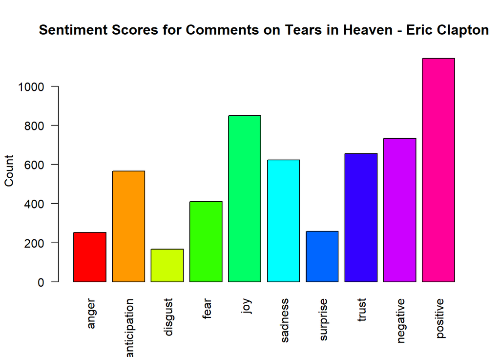

```r
#barplot
barplot(colSums(s),
        las = 2,
        col = rainbow(10),
        ylab = 'Count',
        main = 'Sentiment Scores for Comments on Tears in Heaven - Eric Clapton')
```